# Bayesian

## Prior beliefs are important

- cannot be integrated easily within frequentistic statistics

## The effect of observations

- For a rational person, the role of data in statistics is evidentiary
- Beliefs after observation = Total evidence observed + Beliefs before observation
- That is, we combine observational evidence with beliefs to obtain new beliefs: rational learning

## Some definitions

- Suppose we have beliefs about a parameter θ (a population mean, a variance, a probability…)
- We represent uncertainty with probability distributions
- The uncertainty we have about θ is denoted p(θ)
- Can express ideas like: P(35<θ<100), E(θ), etc…
- Condition on data: Uncertainty in θ after seeing data x is p(θ∣x)

## Using probability theory to change beliefs

- The central inferential principle in Bayesian statistics is Bayes’ theorem  
  \[ p(A∣B)=\frac{p(B∣A) p(A)}{p(B)} \]
- what is the definition of a p-value?

## How should we assess evidence?

- If uncertainty is represented by probability, then can use Bayes’ theorem:  
  \[ p(θ∣data) \propto \frac{p(y\mid\theta)}{p(y)} \times p(\theta)\]
- Beliefs after (posterior) is proportional to likelihood * prior
- prior: how sure we were that θ was true, before we observed the data D
- likelihood: the probability that you would have observed the data, if that hypothesis were true. (kind of like a sampling distribution)
- p(y) is average likelihood, a scaling paramter. Usually intergral.

## Binomial example

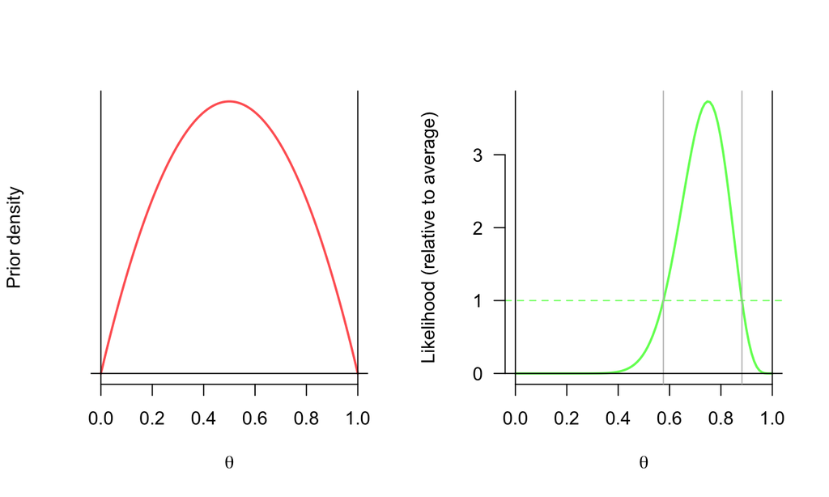

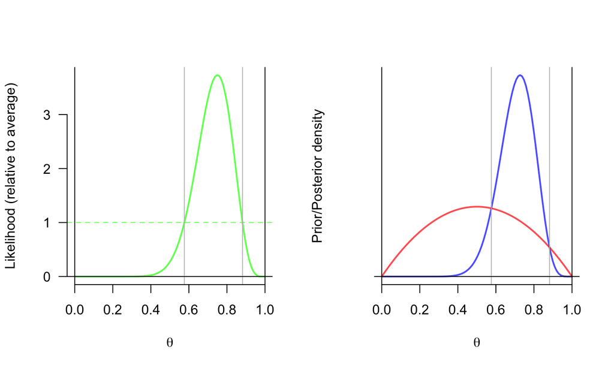

## what does this look like in practice?

- a difficulty in all of these is to compute the posterior distribution
- what you are doing is multiplying a probability distribution by a probability distribution (sometimes many of them)…and you get a distribution in return
1. computationally difficult
2. hard to summarize

## what does this look like in practice?

- Step 1, come up with a descriptive model of the data \[ \hat{y}=\beta_{0}+\beta_{1}X_{1}\]
- i.e. what we have been doing all semester
- Step 2, describe the variation, sigma, \[ y \sim norm(\hat{y},\sigma) \]

## what does this look like in practice?

- Step 3, describe a prior distribution on the parameters
- Could be non-informative, weak, or moderately informative depending on prior knowledge

## what does this look like in practice?

- Step 4, interpret posterior distribution
- Posterior indicates credible values of the parameters \(\beta_{0}, \beta_{1}, \sigma\) consistent with the data
- distribution of parameter values, not data
- can look at range of regression lines ‘consistent with the data’ as opposed to a single best estimate

## what does this look like in practice?

- Step 5, do a posterior prediction check
- Many ways to do this, most typical is to plot predicted data against actual data
- Do so by taking potential \(\beta_{0}, \beta_{1}, \sigma\) values (frequency depending on posterior distribution) and randomly generate X values
- get (average) predicted values and credible ranges around those values. See if actual data make sense given these predicted values

```r
library (brms)
options (mc.cores=parallel::detectCores ()) # Run on multiple cores

b1 <- brm(alcuse ~ peer, data=alcohol1, chains=3, iter=3000)
```

```
##  Family: gaussian
##   Links: mu = identity; sigma = identity
## Formula: alcuse ~ peer
##    Data: alcohol1 (Number of observations: 246)
## Samples: 3 chains, each with iter = 3000; warmup = 1500; thin = 1;
##          total post-warmup samples = 4500
##     ICs: LOO = NA; WAIC = NA; R2 = NA
##
## Population-Level Effects:
##           Estimate Est.Error l-95% CI u-95% CI Eff.Sample Rhat
## Intercept     0.30      0.10     0.10     0.51       4500 1.00
## peer          0.61      0.08     0.44     0.77       4500 1.00
##
## Family Specific Parameters:
##       Estimate Est.Error l-95% CI u-95% CI Eff.Sample Rhat
## sigma     0.97      0.04     0.89     1.06       4438 1.00
##
## Samples were drawn using sampling(NUTS). For each parameter, Eff.Sample
## is a crude measure of effective sample size, and Rhat is the potential
## scale reduction factor on split chains (at convergence, Rhat = 1).
```

```r
lm.1 <- lm(alcuse ~ peer, data = alcohol1)
summary(lm.1)
```

```
##
## Call:
## lm(formula = alcuse ~ peer, data = alcohol1)
##
## Residuals:
##     Min      1Q  Median      3Q     Max
## -1.8405 -0.8472 -0.3039  0.6961  3.1602
##
## Coefficients:
##             Estimate Std. Error t value Pr(>|t|)
## (Intercept)  0.30389    0.10650   2.854  0.00469 **
## peer         0.60739    0.08524   7.126 1.16e-11 ***
## ---
## Signif. codes:  0 '***' 0.001 '**' 0.01 '*' 0.05 '.' 0.1 ' ' 1
##
## Residual standard error: 0.9692 on 244 degrees of freedom
## Multiple R-squared:  0.1723, Adjusted R-squared:  0.1689
## F-statistic: 50.78 on 1 and 244 DF,  p-value: 1.162e-11
```

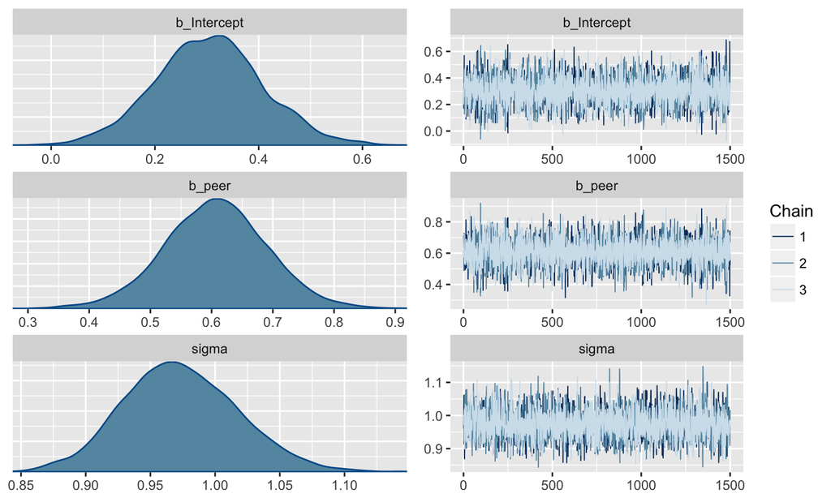

```r
plot(b1)
```

```r
library(shinystan)
launch_shiny(b1)
```

```r
pp_check(b1, re_formula = NA, type = "dens_overlay")
```

```
## Using 10 posterior samples for ppc type 'dens_overlay' by default.
```

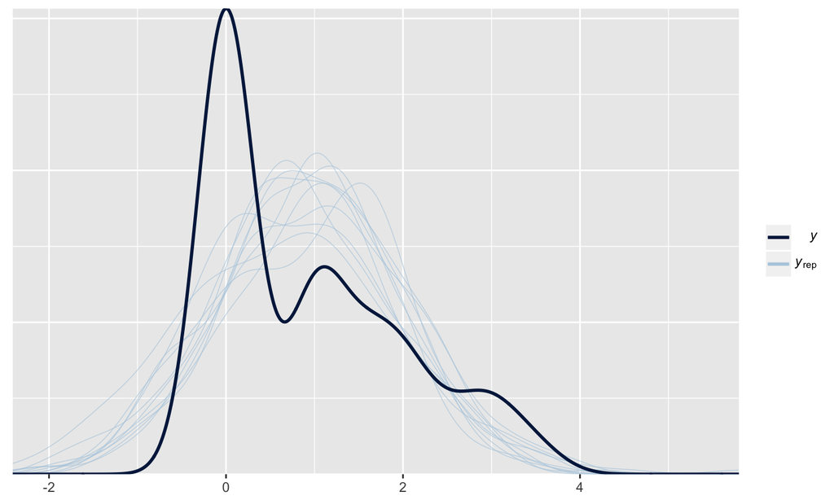

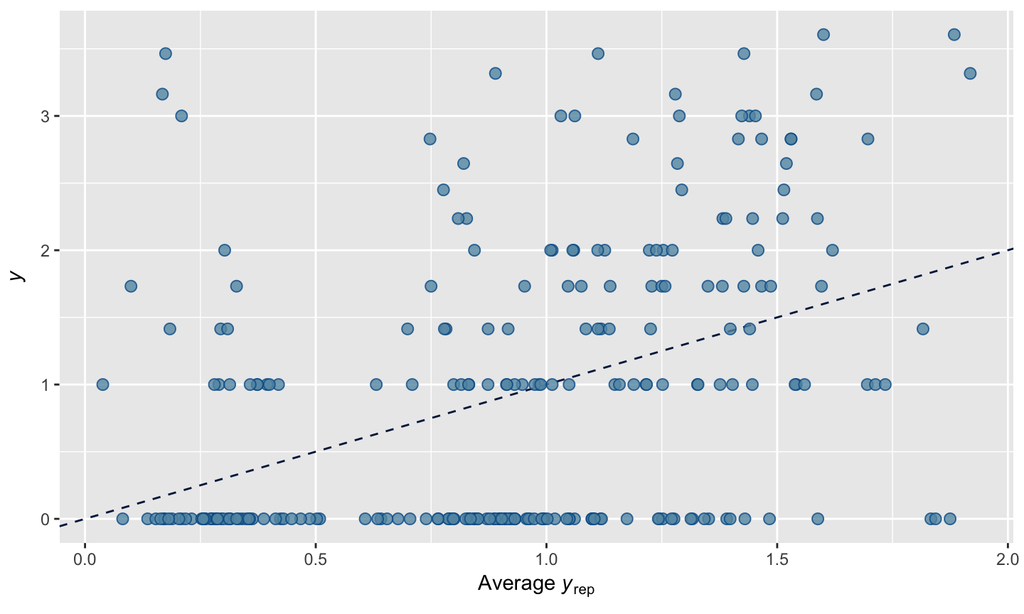

```r
pp_check(b1, type = "scatter_avg", nsamples = 100)
```